# Risk Factor Analysis

## Outcome Variable

**Outcome Variable:** ever_co

## Predictor Variables

**Intervention Variable:** gagebrth

**Adjustment Set:**

unadjusted

## Stratifying Variables

The analysis was stratified on these variable(s):

- agecat
- studyid
- country

## Data Summary

| agecat | studyid | country | gagebrth | ever_co | n_cell | n |
| --- | --- | --- | --- | --- | --- | --- |
| 0-24 months | CMC-V-BCS-2002 | INDIA | Full or late term | 0 | 170 | 351 |
| 0-24 months | CMC-V-BCS-2002 | INDIA | Full or late term | 1 | 45 | 351 |
| 0-24 months | CMC-V-BCS-2002 | INDIA | Preterm | 0 | 35 | 351 |
| 0-24 months | CMC-V-BCS-2002 | INDIA | Preterm | 1 | 17 | 351 |
| 0-24 months | CMC-V-BCS-2002 | INDIA | Early term | 0 | 70 | 351 |
| 0-24 months | CMC-V-BCS-2002 | INDIA | Early term | 1 | 14 | 351 |
| 0-24 months | COHORTS | GUATEMALA | Full or late term | 0 | 406 | 812 |
| 0-24 months | COHORTS | GUATEMALA | Full or late term | 1 | 43 | 812 |
| 0-24 months | COHORTS | GUATEMALA | Preterm | 0 | 105 | 812 |
| 0-24 months | COHORTS | GUATEMALA | Preterm | 1 | 26 | 812 |
| 0-24 months | COHORTS | GUATEMALA | Early term | 0 | 195 | 812 |
| 0-24 months | COHORTS | GUATEMALA | Early term | 1 | 37 | 812 |
| 0-24 months | COHORTS | INDIA | Full or late term | 0 | 550 | 1371 |
| 0-24 months | COHORTS | INDIA | Full or late term | 1 | 41 | 1371 |
| 0-24 months | COHORTS | INDIA | Preterm | 0 | 280 | 1371 |
| 0-24 months | COHORTS | INDIA | Preterm | 1 | 35 | 1371 |
| 0-24 months | COHORTS | INDIA | Early term | 0 | 436 | 1371 |
| 0-24 months | COHORTS | INDIA | Early term | 1 | 29 | 1371 |
| 0-24 months | COHORTS | PHILIPPINES | Full or late term | 0 | 987 | 3019 |
| 0-24 months | COHORTS | PHILIPPINES | Full or late term | 1 | 179 | 3019 |
| 0-24 months | COHORTS | PHILIPPINES | Preterm | 0 | 502 | 3019 |
| 0-24 months | COHORTS | PHILIPPINES | Preterm | 1 | 143 | 3019 |
| 0-24 months | COHORTS | PHILIPPINES | Early term | 0 | 973 | 3019 |
| 0-24 months | COHORTS | PHILIPPINES | Early term | 1 | 235 | 3019 |
| 0-24 months | IRC | INDIA | Full or late term | 0 | 211 | 390 |
| 0-24 months | IRC | INDIA | Full or late term | 1 | 39 | 390 |
| 0-24 months | IRC | INDIA | Preterm | 0 | 28 | 390 |
| 0-24 months | IRC | INDIA | Preterm | 1 | 14 | 390 |
| 0-24 months | IRC | INDIA | Early term | 0 | 78 | 390 |
| 0-24 months | IRC | INDIA | Early term | 1 | 20 | 390 |

[output cut: 132 more lines]

The following strata were considered:

- agecat: 0-24 months, studyid: CMC-V-BCS-2002, country: INDIA
- agecat: 0-24 months, studyid: COHORTS, country: GUATEMALA
- agecat: 0-24 months, studyid: COHORTS, country: INDIA
- agecat: 0-24 months, studyid: COHORTS, country: PHILIPPINES
- agecat: 0-24 months, studyid: IRC, country: INDIA
- agecat: 0-24 months, studyid: Keneba, country: GAMBIA
- agecat: 0-24 months, studyid: NIH-Crypto, country: BANGLADESH
- agecat: 0-24 months, studyid: PROBIT, country: BELARUS
- agecat: 0-24 months, studyid: TanzaniaChild2, country: TANZANIA, UNITED REPUBLIC OF
- agecat: 0-6 months, studyid: CMC-V-BCS-2002, country: INDIA
- agecat: 0-6 months, studyid: COHORTS, country: GUATEMALA
- agecat: 0-6 months, studyid: COHORTS, country: INDIA
- agecat: 0-6 months, studyid: COHORTS, country: PHILIPPINES
- agecat: 0-6 months, studyid: IRC, country: INDIA
- agecat: 0-6 months, studyid: Keneba, country: GAMBIA
- agecat: 0-6 months, studyid: NIH-Crypto, country: BANGLADESH
- agecat: 0-6 months, studyid: PROBIT, country: BELARUS
- agecat: 0-6 months, studyid: TanzaniaChild2, country: TANZANIA, UNITED REPUBLIC OF
- agecat: 6-24 months, studyid: CMC-V-BCS-2002, country: INDIA
- agecat: 6-24 months, studyid: COHORTS, country: GUATEMALA
- agecat: 6-24 months, studyid: COHORTS, country: INDIA
- agecat: 6-24 months, studyid: COHORTS, country: PHILIPPINES
- agecat: 6-24 months, studyid: IRC, country: INDIA
- agecat: 6-24 months, studyid: Keneba, country: GAMBIA
- agecat: 6-24 months, studyid: NIH-Crypto, country: BANGLADESH
- agecat: 6-24 months, studyid: PROBIT, country: BELARUS
- agecat: 6-24 months, studyid: TanzaniaChild2, country: TANZANIA, UNITED REPUBLIC OF

### Dropped Strata

Some strata were dropped due to rare outcomes:

- agecat: 0-24 months, studyid: PROBIT, country: BELARUS
- agecat: 0-6 months, studyid: NIH-Crypto, country: BANGLADESH
- agecat: 0-6 months, studyid: PROBIT, country: BELARUS
- agecat: 0-6 months, studyid: TanzaniaChild2, country: TANZANIA, UNITED REPUBLIC OF
- agecat: 6-24 months, studyid: PROBIT, country: BELARUS

## Methods Detail

We’re interested in the causal parameters $E[Y_a]$ for all values of $a \in \mathcal{A}$. These parameters represent the mean outcome if, possibly contrary to fact, we intervened to set all units to have $A=a$. Under the randomization and positivity assumptions, these are identified by the statistical parameters $\psi_a=E_W[E_{Y|A,W}(Y|A=a,W)]$. In addition, we’re interested in the mean of $Y$, $E[Y]$ under no intervention (the observed mean). We will estimate these parameters by using SuperLearner to fit the relevant likelihood factors – $E_{Y|A,W}(Y|A=a,W)$ and $p(A=a|W)$, and then updating our likelihood fit using a joint TMLE.

For unadjusted analyses ($W=\{\}$), initial likelihoods were estimated using Lrnr_glm to estimate the simple $E(Y|A)$ and Lrnr_mean to estimate $p(A)$. For adjusted analyses, a small library containing Lrnr_glmnet, Lrnr_xgboost, and Lrnr_mean was used.

Having estimated these parameters, we will then use the delta method to estimate relative risks and attributable risks relative to a prespecified baseline level of $A$.

# Results Detail

## Results Plots

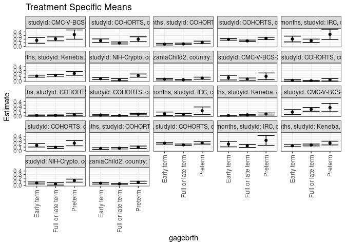

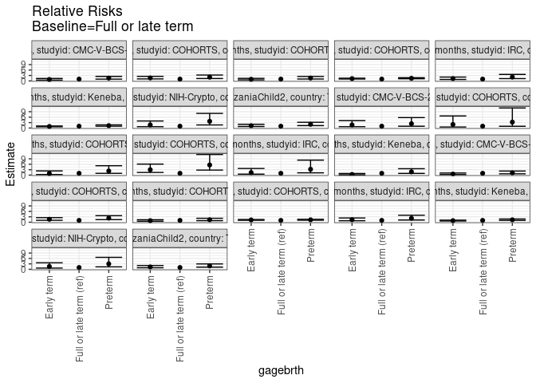

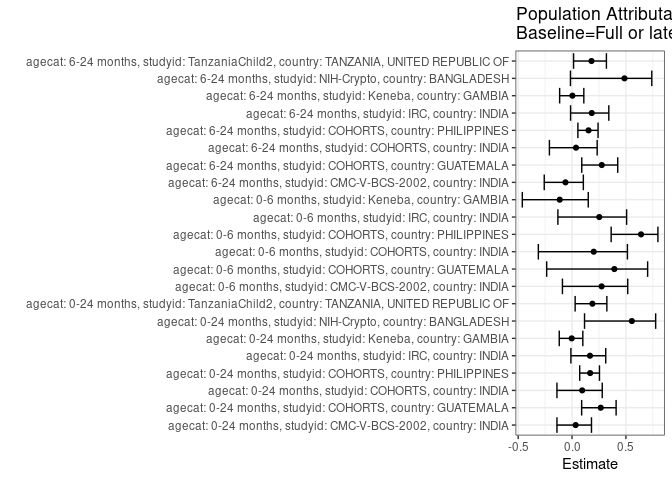

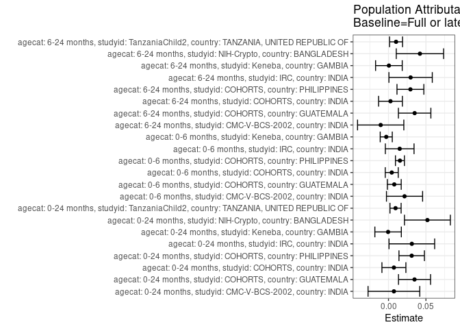

## Results Table

### Parameter: TSM

| agecat | studyid | country | intervention_level | baseline_level | estimate | ci_lower | ci_upper |
| --- | --- | --- | --- | --- | --- | --- | --- |
| 0-24 months | CMC-V-BCS-2002 | INDIA | Full or late term | NA | 0.2093023 | 0.1548470 | 0.2637577 |
| 0-24 months | CMC-V-BCS-2002 | INDIA | Preterm | NA | 0.3269231 | 0.1992436 | 0.4546026 |
| 0-24 months | CMC-V-BCS-2002 | INDIA | Early term | NA | 0.1666667 | 0.0868559 | 0.2464775 |
| 0-24 months | COHORTS | GUATEMALA | Full or late term | NA | 0.0957684 | 0.0685324 | 0.1230044 |
| 0-24 months | COHORTS | GUATEMALA | Preterm | NA | 0.1984733 | 0.1301309 | 0.2668157 |
| 0-24 months | COHORTS | GUATEMALA | Early term | NA | 0.1594828 | 0.1123414 | 0.2066241 |
| 0-24 months | COHORTS | INDIA | Full or late term | NA | 0.0693739 | 0.0488813 | 0.0898666 |
| 0-24 months | COHORTS | INDIA | Preterm | NA | 0.1111111 | 0.0763932 | 0.1458290 |
| 0-24 months | COHORTS | INDIA | Early term | NA | 0.0623656 | 0.0403784 | 0.0843528 |
| 0-24 months | COHORTS | PHILIPPINES | Full or late term | NA | 0.1535163 | 0.1328217 | 0.1742109 |
| 0-24 months | COHORTS | PHILIPPINES | Preterm | NA | 0.2217054 | 0.1896427 | 0.2537681 |
| 0-24 months | COHORTS | PHILIPPINES | Early term | NA | 0.1945364 | 0.1722105 | 0.2168624 |
| 0-24 months | IRC | INDIA | Full or late term | NA | 0.1560000 | 0.1109630 | 0.2010370 |
| 0-24 months | IRC | INDIA | Preterm | NA | 0.3333333 | 0.1905838 | 0.4760829 |
| 0-24 months | IRC | INDIA | Early term | NA | 0.2040816 | 0.1241849 | 0.2839783 |
| 0-24 months | Keneba | GAMBIA | Full or late term | NA | 0.1625148 | 0.1376035 | 0.1874262 |
| 0-24 months | Keneba | GAMBIA | Preterm | NA | 0.2140078 | 0.1638506 | 0.2641649 |
| 0-24 months | Keneba | GAMBIA | Early term | NA | 0.1390728 | 0.1114695 | 0.1666762 |
| 0-24 months | NIH-Crypto | BANGLADESH | Full or late term | NA | 0.0416667 | 0.0114301 | 0.0719033 |
| 0-24 months | NIH-Crypto | BANGLADESH | Preterm | NA | 0.1547170 | 0.1111476 | 0.1982864 |
| 0-24 months | NIH-Crypto | BANGLADESH | Early term | NA | 0.0707692 | 0.0428710 | 0.0986675 |
| 0-24 months | TanzaniaChild2 | TANZANIA, UNITED REPUBLIC OF | Full or late term | NA | 0.0402878 | 0.0299484 | 0.0506271 |
| 0-24 months | TanzaniaChild2 | TANZANIA, UNITED REPUBLIC OF | Preterm | NA | 0.0828571 | 0.0539707 | 0.1117436 |
| 0-24 months | TanzaniaChild2 | TANZANIA, UNITED REPUBLIC OF | Early term | NA | 0.0525292 | 0.0332386 | 0.0718198 |
| 0-6 months | CMC-V-BCS-2002 | INDIA | Full or late term | NA | 0.0566038 | 0.0254523 | 0.0877552 |
| 0-6 months | CMC-V-BCS-2002 | INDIA | Preterm | NA | 0.1346154 | 0.0417130 | 0.2275178 |
| 0-6 months | CMC-V-BCS-2002 | INDIA | Early term | NA | 0.0975610 | 0.0332453 | 0.1618766 |
| 0-6 months | COHORTS | GUATEMALA | Full or late term | NA | 0.0119048 | 0.0015255 | 0.0222840 |
| 0-6 months | COHORTS | GUATEMALA | Preterm | NA | 0.0387597 | 0.0054291 | 0.0720903 |
| 0-6 months | COHORTS | GUATEMALA | Early term | NA | 0.0231481 | 0.0030814 | 0.0432149 |
| 0-6 months | COHORTS | INDIA | Full or late term | NA | 0.0171821 | 0.0066207 | 0.0277436 |
| 0-6 months | COHORTS | INDIA | Preterm | NA | 0.0389610 | 0.0173428 | 0.0605792 |
| 0-6 months | COHORTS | INDIA | Early term | NA | 0.0152838 | 0.0040443 | 0.0265234 |
| 0-6 months | COHORTS | PHILIPPINES | Full or late term | NA | 0.0085763 | 0.0032827 | 0.0138699 |
| 0-6 months | COHORTS | PHILIPPINES | Preterm | NA | 0.0481366 | 0.0316017 | 0.0646716 |
| 0-6 months | COHORTS | PHILIPPINES | Early term | NA | 0.0256623 | 0.0167438 | 0.0345807 |
| 0-6 months | IRC | INDIA | Full or late term | NA | 0.0441767 | 0.0186207 | 0.0697327 |
| 0-6 months | IRC | INDIA | Preterm | NA | 0.1428571 | 0.0368927 | 0.2488215 |
| 0-6 months | IRC | INDIA | Early term | NA | 0.0612245 | 0.0136978 | 0.1087512 |
| 0-6 months | Keneba | GAMBIA | Full or late term | NA | 0.0295250 | 0.0176344 | 0.0414156 |
| 0-6 months | Keneba | GAMBIA | Preterm | NA | 0.0537190 | 0.0253038 | 0.0821343 |
| 0-6 months | Keneba | GAMBIA | Early term | NA | 0.0106383 | 0.0021688 | 0.0191078 |
| 6-24 months | CMC-V-BCS-2002 | INDIA | Full or late term | NA | 0.1813953 | 0.1298133 | 0.2329774 |
| 6-24 months | CMC-V-BCS-2002 | INDIA | Preterm | NA | 0.2307692 | 0.1160904 | 0.3454481 |
| 6-24 months | CMC-V-BCS-2002 | INDIA | Early term | NA | 0.1071429 | 0.0409059 | 0.1733798 |
| 6-24 months | COHORTS | GUATEMALA | Full or late term | NA | 0.0915493 | 0.0641459 | 0.1189527 |
| 6-24 months | COHORTS | GUATEMALA | Preterm | NA | 0.2083333 | 0.1356238 | 0.2810429 |
| 6-24 months | COHORTS | GUATEMALA | Early term | NA | 0.1493213 | 0.1023017 | 0.1963409 |
| 6-24 months | COHORTS | INDIA | Full or late term | NA | 0.0696864 | 0.0488490 | 0.0905239 |
| 6-24 months | COHORTS | INDIA | Preterm | NA | 0.0957096 | 0.0625719 | 0.1288473 |
| 6-24 months | COHORTS | INDIA | Early term | NA | 0.0600000 | 0.0380495 | 0.0819505 |
| 6-24 months | COHORTS | PHILIPPINES | Full or late term | NA | 0.1620370 | 0.1400567 | 0.1840173 |
| 6-24 months | COHORTS | PHILIPPINES | Preterm | NA | 0.2167235 | 0.1833588 | 0.2500883 |
| 6-24 months | COHORTS | PHILIPPINES | Early term | NA | 0.2062500 | 0.1825496 | 0.2299504 |
| 6-24 months | IRC | INDIA | Full or late term | NA | 0.1320000 | 0.0899871 | 0.1740129 |
| 6-24 months | IRC | INDIA | Preterm | NA | 0.2857143 | 0.1489153 | 0.4225133 |
| 6-24 months | IRC | INDIA | Early term | NA | 0.1836735 | 0.1069112 | 0.2604357 |
| 6-24 months | Keneba | GAMBIA | Full or late term | NA | 0.1584767 | 0.1333818 | 0.1835715 |
| 6-24 months | Keneba | GAMBIA | Preterm | NA | 0.2116183 | 0.1600340 | 0.2632025 |
| 6-24 months | Keneba | GAMBIA | Early term | NA | 0.1379310 | 0.1098593 | 0.1660027 |
| 6-24 months | NIH-Crypto | BANGLADESH | Full or late term | NA | 0.0443038 | 0.0121970 | 0.0764106 |
| 6-24 months | NIH-Crypto | BANGLADESH | Preterm | NA | 0.1333333 | 0.0915819 | 0.1750847 |
| 6-24 months | NIH-Crypto | BANGLADESH | Early term | NA | 0.0694006 | 0.0414057 | 0.0973955 |
| 6-24 months | TanzaniaChild2 | TANZANIA, UNITED REPUBLIC OF | Full or late term | NA | 0.0458081 | 0.0337582 | 0.0578581 |
| 6-24 months | TanzaniaChild2 | TANZANIA, UNITED REPUBLIC OF | Preterm | NA | 0.0866667 | 0.0548216 | 0.1185118 |
| 6-24 months | TanzaniaChild2 | TANZANIA, UNITED REPUBLIC OF | Early term | NA | 0.0615034 | 0.0390234 | 0.0839834 |

### Parameter: E(Y)

| agecat | studyid | country | intervention_level | baseline_level | estimate | ci_lower | ci_upper |
| --- | --- | --- | --- | --- | --- | --- | --- |
| 0-24 months | CMC-V-BCS-2002 | INDIA | NA | NA | 0.2165242 | 0.1733743 | 0.2596741 |
| 0-24 months | COHORTS | GUATEMALA | NA | NA | 0.1305419 | 0.1073553 | 0.1537285 |
| 0-24 months | COHORTS | INDIA | NA | NA | 0.0765864 | 0.0625045 | 0.0906684 |
| 0-24 months | COHORTS | PHILIPPINES | NA | NA | 0.1844982 | 0.1706594 | 0.1983369 |
| 0-24 months | IRC | INDIA | NA | NA | 0.1871795 | 0.1484181 | 0.2259409 |
| 0-24 months | Keneba | GAMBIA | NA | NA | 0.1619718 | 0.1444738 | 0.1794699 |
| 0-24 months | NIH-Crypto | BANGLADESH | NA | NA | 0.0936675 | 0.0729118 | 0.1144233 |
| 0-24 months | TanzaniaChild2 | TANZANIA, UNITED REPUBLIC OF | NA | NA | 0.0496894 | 0.0407166 | 0.0586623 |
| 0-6 months | CMC-V-BCS-2002 | INDIA | NA | NA | 0.0780347 | 0.0497312 | 0.1063382 |
| 0-6 months | COHORTS | GUATEMALA | NA | NA | 0.0196078 | 0.0097764 | 0.0294393 |
| 0-6 months | COHORTS | INDIA | NA | NA | 0.0215134 | 0.0137652 | 0.0292615 |
| 0-6 months | COHORTS | PHILIPPINES | NA | NA | 0.0238569 | 0.0184115 | 0.0293022 |
| 0-6 months | IRC | INDIA | NA | NA | 0.0591260 | 0.0356574 | 0.0825946 |
| 0-6 months | Keneba | GAMBIA | NA | NA | 0.0264984 | 0.0185889 | 0.0344079 |
| 6-24 months | CMC-V-BCS-2002 | INDIA | NA | NA | 0.1709402 | 0.1315009 | 0.2103795 |
| 6-24 months | COHORTS | GUATEMALA | NA | NA | 0.1264668 | 0.1029292 | 0.1500043 |
| 6-24 months | COHORTS | INDIA | NA | NA | 0.0723436 | 0.0584002 | 0.0862871 |
| 6-24 months | COHORTS | PHILIPPINES | NA | NA | 0.1913137 | 0.1767054 | 0.2059220 |
| 6-24 months | IRC | INDIA | NA | NA | 0.1615385 | 0.1249661 | 0.1981108 |
| 6-24 months | Keneba | GAMBIA | NA | NA | 0.1590214 | 0.1412900 | 0.1767528 |
| 6-24 months | NIH-Crypto | BANGLADESH | NA | NA | 0.0863014 | 0.0659171 | 0.1066856 |
| 6-24 months | TanzaniaChild2 | TANZANIA, UNITED REPUBLIC OF | NA | NA | 0.0559072 | 0.0455633 | 0.0662511 |

### Parameter: RR

| agecat | studyid | country | intervention_level | baseline_level | estimate | ci_lower | ci_upper |
| --- | --- | --- | --- | --- | --- | --- | --- |
| 0-24 months | CMC-V-BCS-2002 | INDIA | Full or late term | Full or late term | 1.0000000 | 1.0000000 | 1.000000 |
| 0-24 months | CMC-V-BCS-2002 | INDIA | Preterm | Full or late term | 1.5619658 | 0.9769393 | 2.497327 |
| 0-24 months | CMC-V-BCS-2002 | INDIA | Early term | Full or late term | 0.7962963 | 0.4617352 | 1.373271 |
| 0-24 months | COHORTS | GUATEMALA | Full or late term | Full or late term | 1.0000000 | 1.0000000 | 1.000000 |
| 0-24 months | COHORTS | GUATEMALA | Preterm | Full or late term | 2.0724303 | 1.3259419 | 3.239182 |
| 0-24 months | COHORTS | GUATEMALA | Early term | Full or late term | 1.6652967 | 1.1049683 | 2.509767 |
| 0-24 months | COHORTS | INDIA | Full or late term | Full or late term | 1.0000000 | 1.0000000 | 1.000000 |
| 0-24 months | COHORTS | INDIA | Preterm | Full or late term | 1.6016260 | 1.0418845 | 2.462083 |
| 0-24 months | COHORTS | INDIA | Early term | Full or late term | 0.8989772 | 0.5675396 | 1.423971 |
| 0-24 months | COHORTS | PHILIPPINES | Full or late term | Full or late term | 1.0000000 | 1.0000000 | 1.000000 |
| 0-24 months | COHORTS | PHILIPPINES | Preterm | Full or late term | 1.4441817 | 1.1851146 | 1.759881 |
| 0-24 months | COHORTS | PHILIPPINES | Early term | Full or late term | 1.2672037 | 1.0615954 | 1.512634 |
| 0-24 months | IRC | INDIA | Full or late term | Full or late term | 1.0000000 | 1.0000000 | 1.000000 |
| 0-24 months | IRC | INDIA | Preterm | Full or late term | 2.1367521 | 1.2748323 | 3.581420 |
| 0-24 months | IRC | INDIA | Early term | Full or late term | 1.3082156 | 0.8043136 | 2.127812 |
| 0-24 months | Keneba | GAMBIA | Full or late term | Full or late term | 1.0000000 | 1.0000000 | 1.000000 |
| 0-24 months | Keneba | GAMBIA | Preterm | Full or late term | 1.3168508 | 0.9952076 | 1.742447 |
| 0-24 months | Keneba | GAMBIA | Early term | Full or late term | 0.8557548 | 0.6659417 | 1.099670 |
| 0-24 months | NIH-Crypto | BANGLADESH | Full or late term | Full or late term | 1.0000000 | 1.0000000 | 1.000000 |
| 0-24 months | NIH-Crypto | BANGLADESH | Preterm | Full or late term | 3.7132075 | 1.7048770 | 8.087334 |
| 0-24 months | NIH-Crypto | BANGLADESH | Early term | Full or late term | 1.6984615 | 0.7436993 | 3.878949 |
| 0-24 months | TanzaniaChild2 | TANZANIA, UNITED REPUBLIC OF | Full or late term | Full or late term | 1.0000000 | 1.0000000 | 1.000000 |
| 0-24 months | TanzaniaChild2 | TANZANIA, UNITED REPUBLIC OF | Preterm | Full or late term | 2.0566327 | 1.3339793 | 3.170767 |
| 0-24 months | TanzaniaChild2 | TANZANIA, UNITED REPUBLIC OF | Early term | Full or late term | 1.3038494 | 0.8330155 | 2.040806 |
| 0-6 months | CMC-V-BCS-2002 | INDIA | Full or late term | Full or late term | 1.0000000 | 1.0000000 | 1.000000 |
| 0-6 months | CMC-V-BCS-2002 | INDIA | Preterm | Full or late term | 2.3782051 | 0.9837792 | 5.749115 |
| 0-6 months | CMC-V-BCS-2002 | INDIA | Early term | Full or late term | 1.7235772 | 0.7302577 | 4.068041 |
| 0-6 months | COHORTS | GUATEMALA | Full or late term | Full or late term | 1.0000000 | 1.0000000 | 1.000000 |
| 0-6 months | COHORTS | GUATEMALA | Preterm | Full or late term | 3.2558140 | 0.9568134 | 11.078779 |
| 0-6 months | COHORTS | GUATEMALA | Early term | Full or late term | 1.9444444 | 0.5686405 | 6.648953 |
| 0-6 months | COHORTS | INDIA | Full or late term | Full or late term | 1.0000000 | 1.0000000 | 1.000000 |
| 0-6 months | COHORTS | INDIA | Preterm | Full or late term | 2.2675325 | 0.9906640 | 5.190159 |
| 0-6 months | COHORTS | INDIA | Early term | Full or late term | 0.8895197 | 0.3411203 | 2.319549 |
| 0-6 months | COHORTS | PHILIPPINES | Full or late term | Full or late term | 1.0000000 | 1.0000000 | 1.000000 |
| 0-6 months | COHORTS | PHILIPPINES | Preterm | Full or late term | 5.6127329 | 2.7694809 | 11.374973 |
| 0-6 months | COHORTS | PHILIPPINES | Early term | Full or late term | 2.9922185 | 1.4735405 | 6.076095 |
| 0-6 months | IRC | INDIA | Full or late term | Full or late term | 1.0000000 | 1.0000000 | 1.000000 |
| 0-6 months | IRC | INDIA | Preterm | Full or late term | 3.2337662 | 1.2623595 | 8.283888 |
| 0-6 months | IRC | INDIA | Early term | Full or late term | 1.3858998 | 0.5263615 | 3.649048 |
| 0-6 months | Keneba | GAMBIA | Full or late term | Full or late term | 1.0000000 | 1.0000000 | 1.000000 |
| 0-6 months | Keneba | GAMBIA | Preterm | Full or late term | 1.8194395 | 0.9358545 | 3.537259 |
| 0-6 months | Keneba | GAMBIA | Early term | Full or late term | 0.3603145 | 0.1476399 | 0.879346 |
| 6-24 months | CMC-V-BCS-2002 | INDIA | Full or late term | Full or late term | 1.0000000 | 1.0000000 | 1.000000 |
| 6-24 months | CMC-V-BCS-2002 | INDIA | Preterm | Full or late term | 1.2721893 | 0.7176235 | 2.255313 |
| 6-24 months | CMC-V-BCS-2002 | INDIA | Early term | Full or late term | 0.5906593 | 0.2990956 | 1.166445 |
| 6-24 months | COHORTS | GUATEMALA | Full or late term | Full or late term | 1.0000000 | 1.0000000 | 1.000000 |
| 6-24 months | COHORTS | GUATEMALA | Preterm | Full or late term | 2.2756410 | 1.4368823 | 3.604013 |
| 6-24 months | COHORTS | GUATEMALA | Early term | Full or late term | 1.6310477 | 1.0562926 | 2.518541 |
| 6-24 months | COHORTS | INDIA | Full or late term | Full or late term | 1.0000000 | 1.0000000 | 1.000000 |
| 6-24 months | COHORTS | INDIA | Preterm | Full or late term | 1.3734323 | 0.8692132 | 2.170142 |
| 6-24 months | COHORTS | INDIA | Early term | Full or late term | 0.8610000 | 0.5367858 | 1.381037 |
| 6-24 months | COHORTS | PHILIPPINES | Full or late term | Full or late term | 1.0000000 | 1.0000000 | 1.000000 |
| 6-24 months | COHORTS | PHILIPPINES | Preterm | Full or late term | 1.3374939 | 1.0893821 | 1.642114 |
| 6-24 months | COHORTS | PHILIPPINES | Early term | Full or late term | 1.2728571 | 1.0655434 | 1.520506 |
| 6-24 months | IRC | INDIA | Full or late term | Full or late term | 1.0000000 | 1.0000000 | 1.000000 |
| 6-24 months | IRC | INDIA | Preterm | Full or late term | 2.1645022 | 1.2180576 | 3.846345 |
| 6-24 months | IRC | INDIA | Early term | Full or late term | 1.3914657 | 0.8228622 | 2.352978 |
| 6-24 months | Keneba | GAMBIA | Full or late term | Full or late term | 1.0000000 | 1.0000000 | 1.000000 |
| 6-24 months | Keneba | GAMBIA | Preterm | Full or late term | 1.3353276 | 0.9984988 | 1.785781 |
| 6-24 months | Keneba | GAMBIA | Early term | Full or late term | 0.8703555 | 0.6725222 | 1.126385 |
| 6-24 months | NIH-Crypto | BANGLADESH | Full or late term | Full or late term | 1.0000000 | 1.0000000 | 1.000000 |
| 6-24 months | NIH-Crypto | BANGLADESH | Preterm | Full or late term | 3.0095238 | 1.3666005 | 6.627565 |
| 6-24 months | NIH-Crypto | BANGLADESH | Early term | Full or late term | 1.5664714 | 0.6834694 | 3.590260 |
| 6-24 months | TanzaniaChild2 | TANZANIA, UNITED REPUBLIC OF | Full or late term | Full or late term | 1.0000000 | 1.0000000 | 1.000000 |
| 6-24 months | TanzaniaChild2 | TANZANIA, UNITED REPUBLIC OF | Preterm | Full or late term | 1.8919497 | 1.2040734 | 2.972803 |
| 6-24 months | TanzaniaChild2 | TANZANIA, UNITED REPUBLIC OF | Early term | Full or late term | 1.3426312 | 0.8558210 | 2.106350 |

### Parameter: PAR

| agecat | studyid | country | intervention_level | baseline_level | estimate | ci_lower | ci_upper |
| --- | --- | --- | --- | --- | --- | --- | --- |
| 0-24 months | CMC-V-BCS-2002 | INDIA | Full or late term | NA | 0.0072219 | -0.0273396 | 0.0417833 |
| 0-24 months | COHORTS | GUATEMALA | Full or late term | NA | 0.0347735 | 0.0133480 | 0.0561990 |
| 0-24 months | COHORTS | INDIA | Full or late term | NA | 0.0072125 | -0.0087935 | 0.0232185 |
| 0-24 months | COHORTS | PHILIPPINES | Full or late term | NA | 0.0309819 | 0.0139829 | 0.0479809 |
| 0-24 months | IRC | INDIA | Full or late term | NA | 0.0311795 | 0.0006778 | 0.0616812 |
| 0-24 months | Keneba | GAMBIA | Full or late term | NA | -0.0005430 | -0.0182274 | 0.0171414 |
| 0-24 months | NIH-Crypto | BANGLADESH | Full or late term | NA | 0.0520009 | 0.0213449 | 0.0826569 |
| 0-24 months | TanzaniaChild2 | TANZANIA, UNITED REPUBLIC OF | Full or late term | NA | 0.0094017 | 0.0019474 | 0.0168559 |
| 0-6 months | CMC-V-BCS-2002 | INDIA | Full or late term | NA | 0.0214309 | -0.0027005 | 0.0455623 |
| 0-6 months | COHORTS | GUATEMALA | Full or late term | NA | 0.0077031 | -0.0015757 | 0.0169818 |
| 0-6 months | COHORTS | INDIA | Full or late term | NA | 0.0043312 | -0.0043440 | 0.0130064 |
| 0-6 months | COHORTS | PHILIPPINES | Full or late term | NA | 0.0152805 | 0.0092788 | 0.0212823 |
| 0-6 months | IRC | INDIA | Full or late term | NA | 0.0149493 | -0.0042281 | 0.0341266 |
| 0-6 months | Keneba | GAMBIA | Full or late term | NA | -0.0030266 | -0.0110869 | 0.0050337 |
| 6-24 months | CMC-V-BCS-2002 | INDIA | Full or late term | NA | -0.0104552 | -0.0413843 | 0.0204739 |
| 6-24 months | COHORTS | GUATEMALA | Full or late term | NA | 0.0349175 | 0.0132196 | 0.0566153 |
| 6-24 months | COHORTS | INDIA | Full or late term | NA | 0.0026572 | -0.0132484 | 0.0185629 |
| 6-24 months | COHORTS | PHILIPPINES | Full or late term | NA | 0.0292767 | 0.0113335 | 0.0472199 |
| 6-24 months | IRC | INDIA | Full or late term | NA | 0.0295385 | 0.0005610 | 0.0585159 |
| 6-24 months | Keneba | GAMBIA | Full or late term | NA | 0.0005447 | -0.0172625 | 0.0183520 |
| 6-24 months | NIH-Crypto | BANGLADESH | Full or late term | NA | 0.0419976 | 0.0103726 | 0.0736225 |
| 6-24 months | TanzaniaChild2 | TANZANIA, UNITED REPUBLIC OF | Full or late term | NA | 0.0100990 | 0.0014397 | 0.0187584 |

### Parameter: PAF

| agecat | studyid | country | intervention_level | baseline_level | estimate | ci_lower | ci_upper |
| --- | --- | --- | --- | --- | --- | --- | --- |
| 0-24 months | CMC-V-BCS-2002 | INDIA | Full or late term | NA | 0.0333537 | -0.1401246 | 0.1804361 |
| 0-24 months | COHORTS | GUATEMALA | Full or late term | NA | 0.2663781 | 0.0891787 | 0.4091035 |
| 0-24 months | COHORTS | INDIA | Full or late term | NA | 0.0941745 | -0.1401256 | 0.2803251 |
| 0-24 months | COHORTS | PHILIPPINES | Full or late term | NA | 0.1679251 | 0.0710950 | 0.2546616 |
| 0-24 months | IRC | INDIA | Full or late term | NA | 0.1665753 | -0.0106502 | 0.3127230 |
| 0-24 months | Keneba | GAMBIA | Full or late term | NA | -0.0033524 | -0.1186957 | 0.1000984 |
| 0-24 months | NIH-Crypto | BANGLADESH | Full or late term | NA | 0.5551643 | 0.1158430 | 0.7761950 |
| 0-24 months | TanzaniaChild2 | TANZANIA, UNITED REPUBLIC OF | Full or late term | NA | 0.1892086 | 0.0287439 | 0.3231624 |
| 0-6 months | CMC-V-BCS-2002 | INDIA | Full or late term | NA | 0.2746331 | -0.0891296 | 0.5169013 |
| 0-6 months | COHORTS | GUATEMALA | Full or late term | NA | 0.3928571 | -0.2355181 | 0.7016455 |
| 0-6 months | COHORTS | INDIA | Full or late term | NA | 0.2013272 | -0.3127887 | 0.5141044 |
| 0-6 months | COHORTS | PHILIPPINES | Full or late term | NA | 0.6405089 | 0.3630151 | 0.7971162 |
| 0-6 months | IRC | INDIA | Full or late term | NA | 0.2528374 | -0.1313107 | 0.5065442 |
| 0-6 months | Keneba | GAMBIA | Full or late term | NA | -0.1142185 | -0.4616076 | 0.1506046 |
| 6-24 months | CMC-V-BCS-2002 | INDIA | Full or late term | NA | -0.0611628 | -0.2580714 | 0.1049264 |
| 6-24 months | COHORTS | GUATEMALA | Full or late term | NA | 0.2760999 | 0.0903101 | 0.4239451 |
| 6-24 months | COHORTS | INDIA | Full or late term | NA | 0.0367305 | -0.2101244 | 0.2332292 |
| 6-24 months | COHORTS | PHILIPPINES | Full or late term | NA | 0.1530297 | 0.0543385 | 0.2414213 |
| 6-24 months | IRC | INDIA | Full or late term | NA | 0.1828571 | -0.0136344 | 0.3412591 |
| 6-24 months | Keneba | GAMBIA | Full or late term | NA | 0.0034256 | -0.1150878 | 0.1093432 |
| 6-24 months | NIH-Crypto | BANGLADESH | Full or late term | NA | 0.4866385 | -0.0147040 | 0.7402790 |
| 6-24 months | TanzaniaChild2 | TANZANIA, UNITED REPUBLIC OF | Full or late term | NA | 0.1806396 | 0.0141114 | 0.3190392 |